# Aeroporti e Rotte aeroportuali

10-02-2025

## Dataset

## Fonte

I dati sugli aeroporti e le rotte mondiali sono stati ottenuti dal repository del portale [OpenFlights](https://github.com/jpatokal/openflights).

OpenFlights è uno strumento che permette di tenere traccia dei propri viaggi in tutto il mondo, cercarli e filtrarli in molti modi interessanti, calcolare automaticamente le statistiche e condividere le mappe risultanti con le rotte in evidenza. E’ possibile controllare le mappe delle rotte aeroportuali per quasi tutti gli aeroporti del mondo e scoprire le tratte che le compagnie aeree coprono.

I dati messi a disposizione riguardano:

- [aeroporti](https://raw.githubusercontent.com/jpatokal/openflights/master/data/airports.dat)
- [rotte aeree](https://raw.githubusercontent.com/jpatokal/openflights/master/data/routes.dat)
- compagnie aeree
- aeroplani

## Informazioni principali contenute nei dataset

### **Airports**

- `Name`: Nome ufficiale dell’aeroporto.
- `City`: Città in cui si trova l’aeroporto.
- `Country`: Paese in cui si trova l’aeroporto.
- `IATA`: Codice aeroportuale IATA (International Air Transport Association).
- `Latitude`: Latitudine geografica.
- `Longitude`: Longitudine geografica.

### **Routes**

- `Source_airport`: Aeroporto di partenza della rotta.
- `Destination_airport`: Aeroporto di arrivo della rotta.

## Esempio di `airports` e `routes`

| Airports IATA | Airports Name | Airports City | Airports Country | Airports Latitude | Airports Longitude |
| --- | --- | --- | --- | --- | --- |
| DDC | Dodge City Regional Airport | Dodge City | United States | 37.7634 | -99.9656 |
| AES | Ålesund Airport | Alesund | Norway | 62.5625 | 6.1197 |
| MEH | Mehamn Airport | Mehamn | Norway | 71.0297 | 27.8267 |
| VPE | Ngjiva Pereira Airport | Ondjiva | Angola | -17.0435 | 15.6838 |
| OHO | Okhotsk Airport | Okhotsk | Russia | 59.4101 | 143.0565 |

| Routes Source Airport | Routes Destination Airport |
| --- | --- |
| KWI | CMB |
| ZAH | MHD |
| BTH | DJB |
| PFO | GPA |
| JOG | SIN |

## Visualizzazione di qualche dato

### Distribuzione degli aereoporti per stato

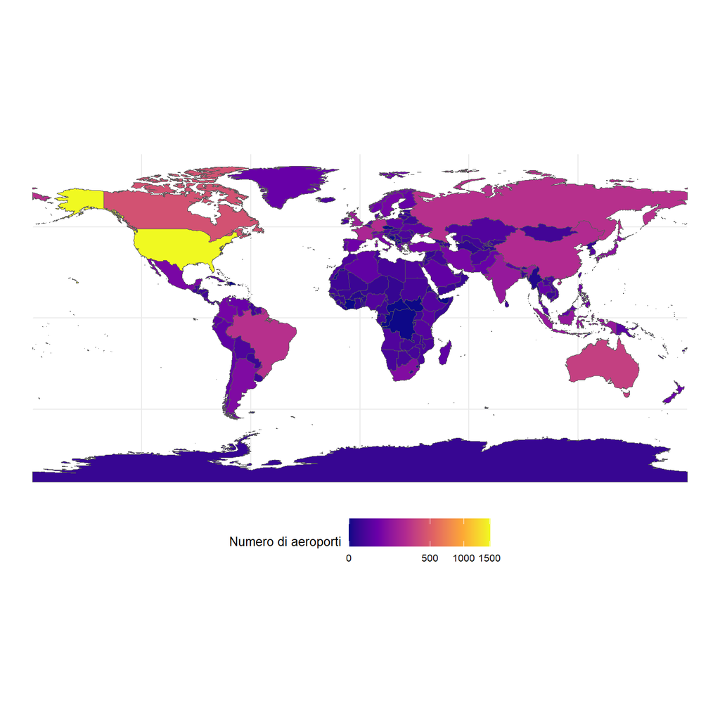

Le prime 8 nazioni con più aeroporti

| Country | Frequenza |
| --- | --- |
| United States of America | 1512 |
| Canada | 430 |
| Australia | 334 |
| Brazil | 264 |
| Russia | 264 |
| Germany | 249 |
| China | 241 |
| France | 217 |

### Visualizzazione degli aeroporti per numero di rotte di partenza e destinazione

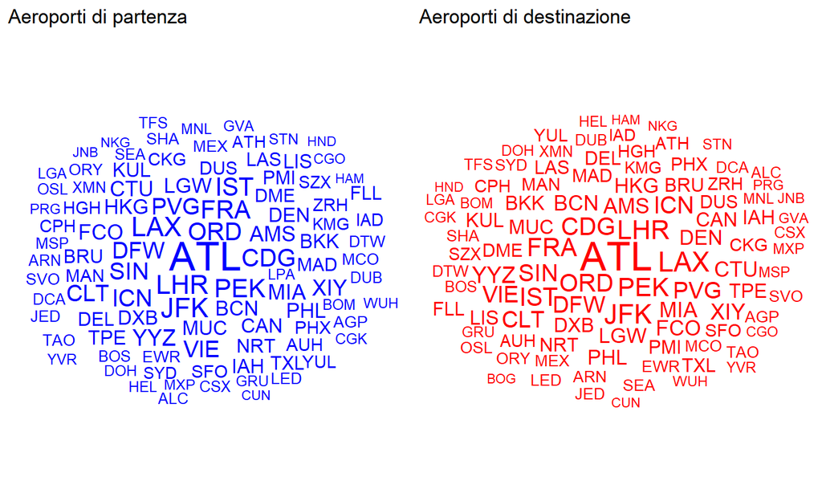

## La rete degli aeroporti

I nodi sono rappresentati dal codice IATA degli aeroporti

Gli archi sono rappresentati da ogni tratta dove la sorgente e la destinazioni sono i codici IATA degli aeroporti

### Il grafo

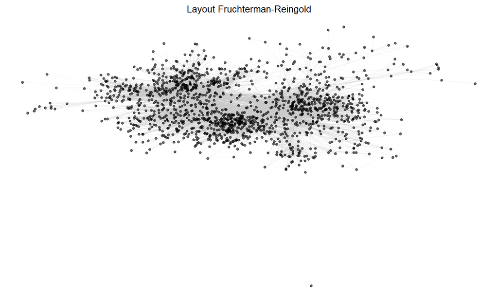

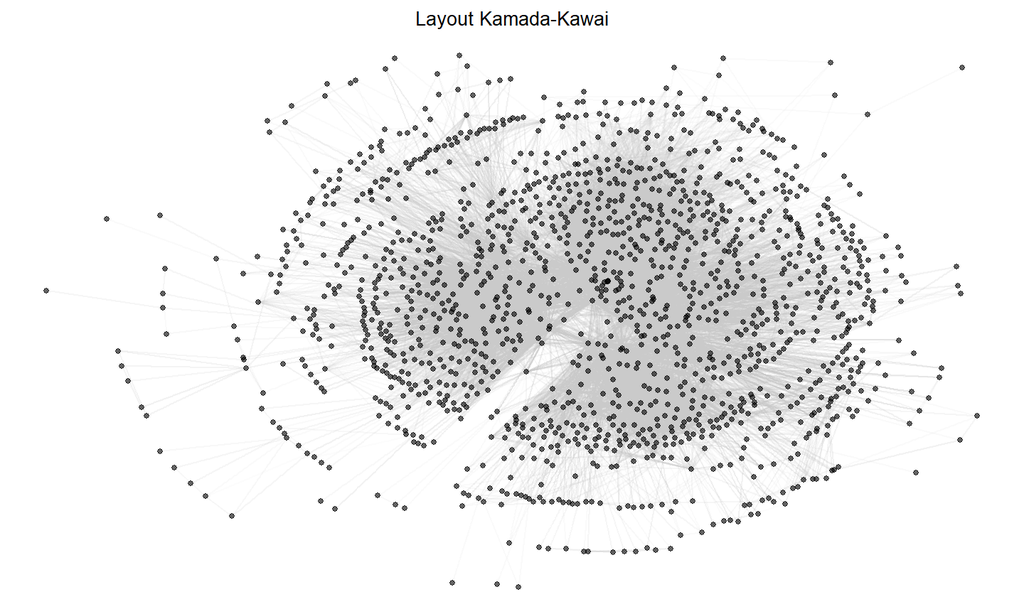

### Il grafo nel planisfero

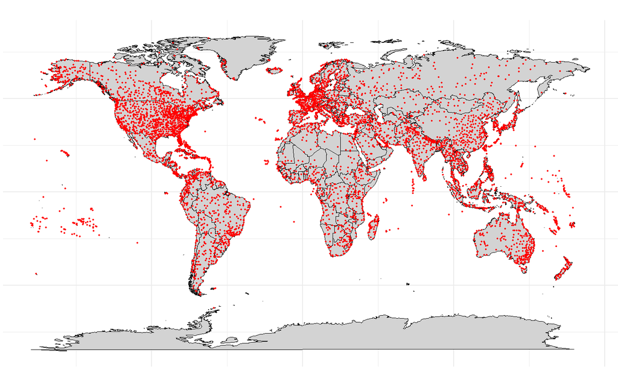

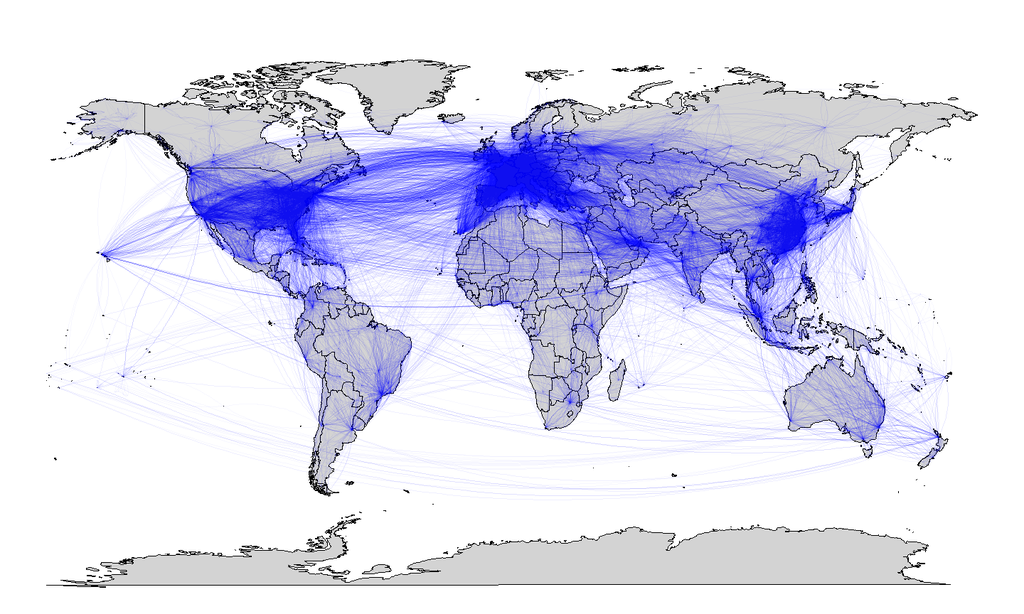

### Il grafo italiano

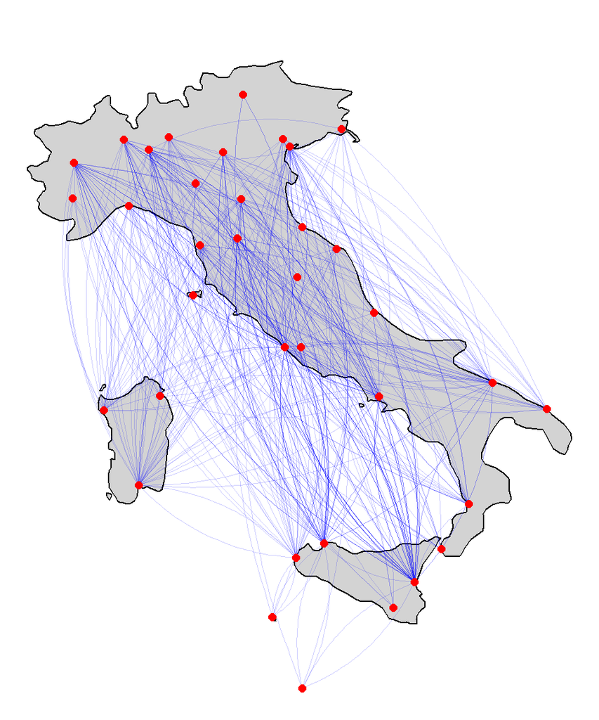

## Analisi preventiva

## Pulizia dei dati

### Rimozione degli aeroporti senza connessioni

La rete è composta da 6072 aeroporti, di cui 2815 senza connessioni e 3257 con almeno una connessione.

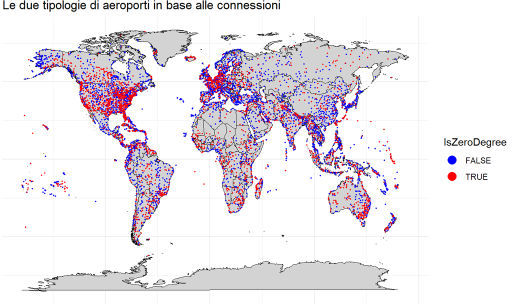

La distribuzione delle connessioni:

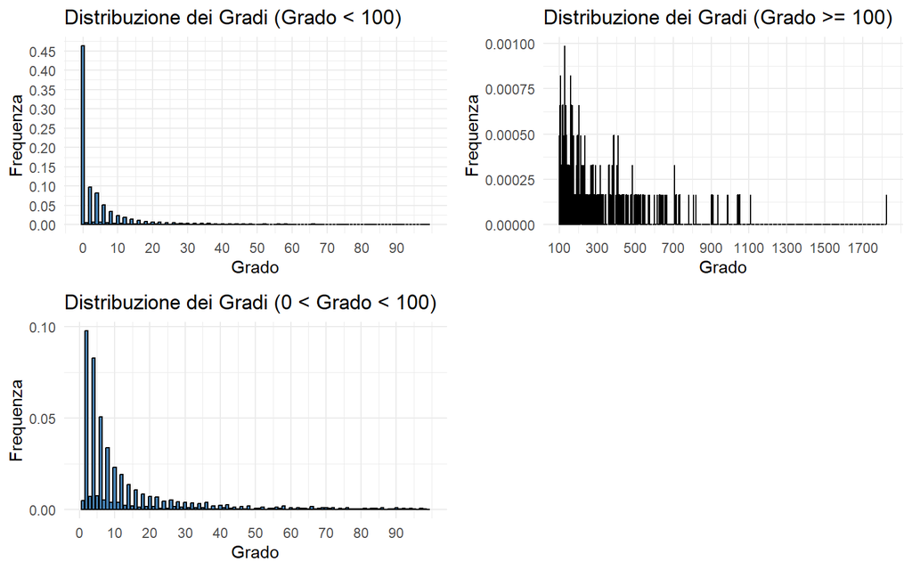

Il numero degli aeroporti con grado minore di 100 è 5759 su un totale di 6072.

Analizziamo numericamente la distribuzione per verificare se segue una distribuzione power-law.

La stima dell’esponente è 4.6125912, distante da un valore compreso tra 2 e 3 tipico.

Stimiamo l’esponente della distribuzione esponenziale: questo valore è 0.0041231. Essendo minore di 0.01, quindi la distribuzione è meno larga e potrebbe essere non adatta.

La distribuzione esponenziale sembra adattarsi leggermente meglio della power-law, ma la differenza, che vale -0.0446544, non è statisticamente significativa. Esse sono molto simili nel descrivere i dati, una non è superiore all’altra.

Il test di verifica se la power-law è significativamente meglio della distribuzione esponenziale possiede p-value 0.5178086 e indica che non c’è una forte evidenza che una distribuzione sia nettamente migliore dell’altra.

Il test di verifica se le distribuzioni hanno differenze significative possiede p-value 0.9643828 e conferma che la differenza tra le distribuzioni è molto piccola.

In sintesi, la rete non mostra una chiara superiorità di adattamento né alla power-law né alla distribuzione esponenziale.

### **Assortatività della rete**

L’assortività, pari a 0.0053039, è un valore molto vicino a zero, il che indica che la rete non mostra una tendenza significativa a favorire connessioni tra aeroporti con gradi simili.

La struttura della rete dipende più dalla geografia o dalle rotte commerciali che da una scelta basata sul grado.

## Analisi della rete

## Quali sono le dimensioni e le caratteristiche della rete?

Dimensioni e caratteristiche:

- Il grafo ha 3257 nodi e 66933 archi.
- La densità del grafo è 0.0063116.
- Il diametro del grafo è 13.
- Il numero di componenti connesse è 7.
- Il grafo è fortemente connesso? FALSE.
- Il grafo è debolmente connesso? FALSE.

## Qual è la topologia della rete degli aeroporti? È una rete completamente connessa o esistono componenti isolate?

La rete degli aeroporti presenta una struttura complessa con una componente fortemente connessa principale e alcune componenti isolate.

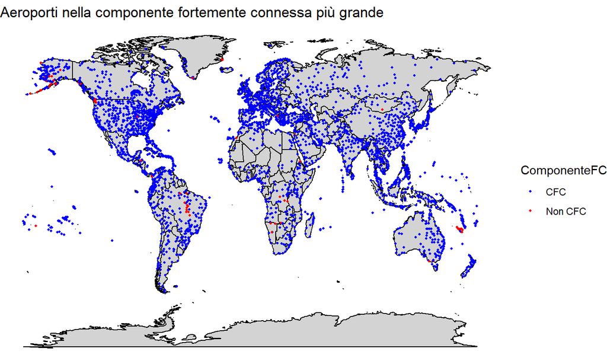

Il numero totale di componenti fortemente connesse è 48. La componente fortemente connessa più grande è quella di indice 28, composta da 3190 nodi. I rimanenti 67 nodi si dividono tra i nodi isolati, cioè le componenti di dimensione 1 di numero 41, e le altre componenti fortemente connesse: una di dimensione 10, tre di dimensione 4 e due di dimensione 2.

## E’ una rete piccolo mondo?

Consideriamo il grafo composto dai soli nodi della Componente Fortemente Connessa più grande.

Il grafo analizzato mostra un **coefficiente di clustering** significativamente più alto rispetto al grafo casuale, 0.6326606 contro 0.0128119 e il loro rapporto 49.3806419 indica una struttura altamente aggregata.

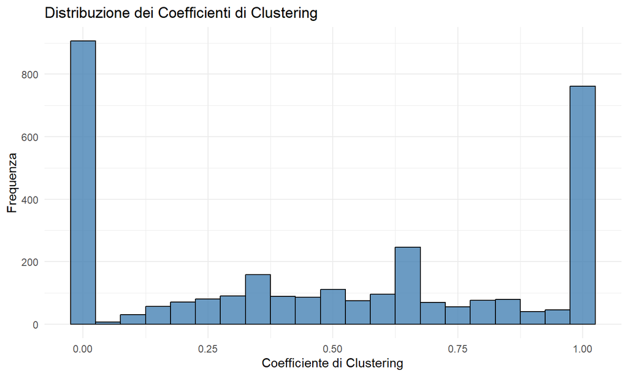

Tuttavia, il rapporto della **lunghezza media dei cammini** ( 3.9954224 / 2.5676112 = 1.5560855 ) suggerisce che le connessioni globali non sono abbastanza efficienti per essere considerate “Small-World” nel senso stretto.

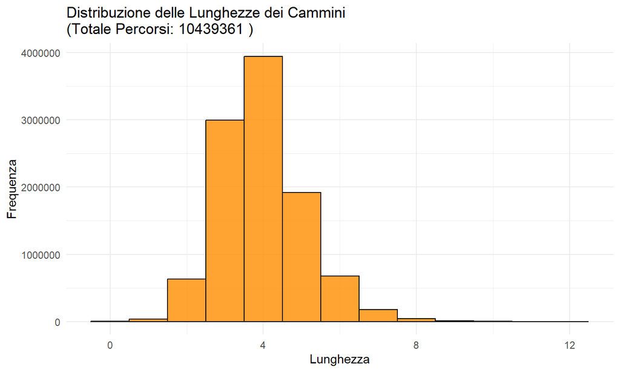

Lo **SmallWorldRatio**, considerando il suo valore uguale a 31.7338881, si può dire che è significativamente maggiore di 1, e quindi il grafo presenta una struttura che combina sia un elevato coefficiente di clustering che una bassa lunghezza media dei cammini, tipica delle reti small-world.

Considerando tutto però, non si può dare un’indicazione precisa sulla tipologia della rete. Sembra small-world con un clustering elevato e una lunghezza dei cammini non eccessivamente alta, ma non del tutto visto che la metrica diretta C/L vale 0.1583463 e la distribuzione dei gradi non segue una Poisson (e neanche una power-law).

## Come gli aeroporti si dividono in comunità?

Analisi delle comunità tramite l’algoritmo di Louvain.

### Mondo

| 4 | Indici e Valori 3 | Indici e Valori 18 | Indici e Valori 8 | Indici e Valori 10 | Indici e Valori 1 | Indici e Valori 7 | Indici e Valori 12 | Indici e Valori 19 |
| --- | --- | --- | --- | --- | --- | --- | --- | --- |
| 675 | 532 | 495 | 290 | 277 | 239 | 199 | 162 | 131 |

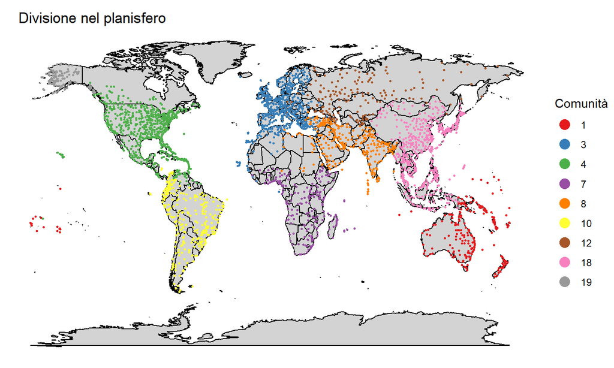

Vengono esclusi 257 nodi che formano 15 comunità.

Considerando che l’algoritmo ha trovato una partizione con modularità finale pari a 0.6597137 si può dire che la suddivisione in comunità è significativa.

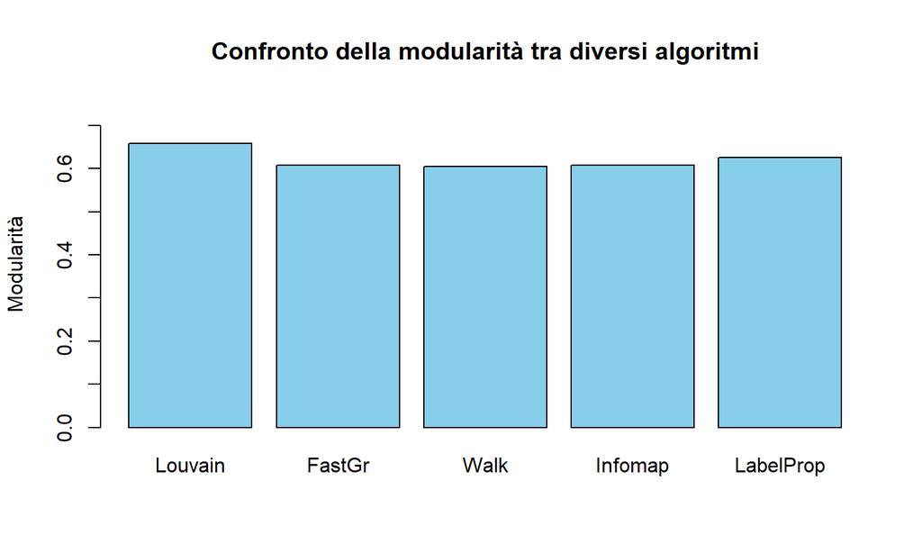

### Europa

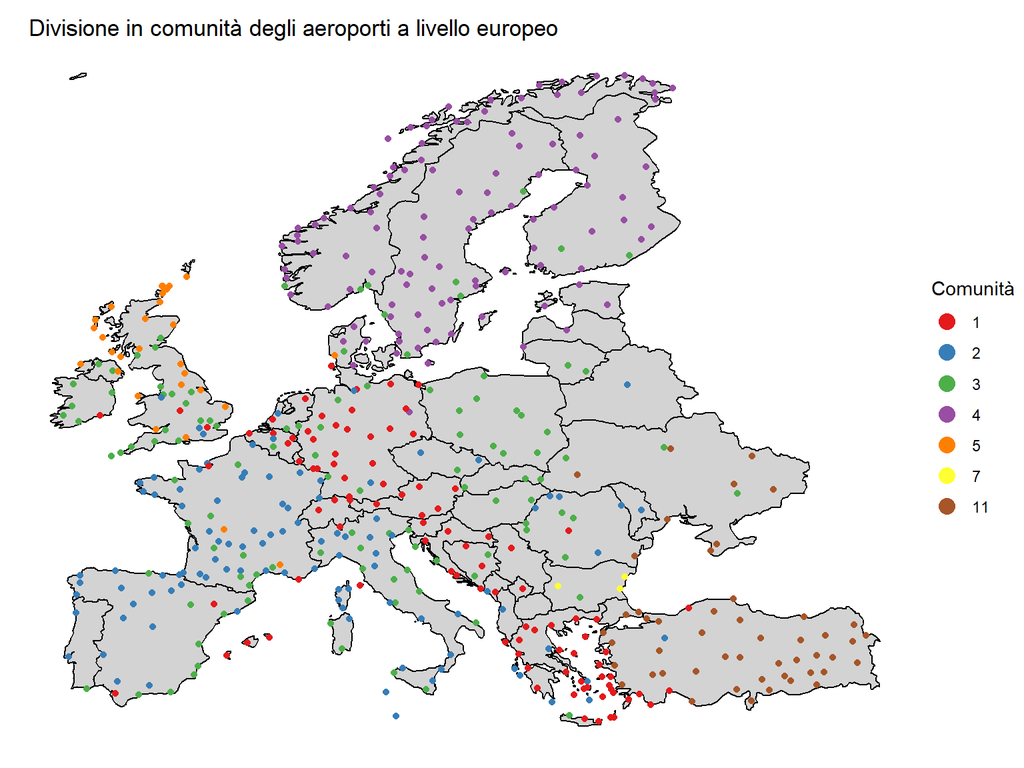

Vengono esclusi 5 nodi che formano comunità singole.

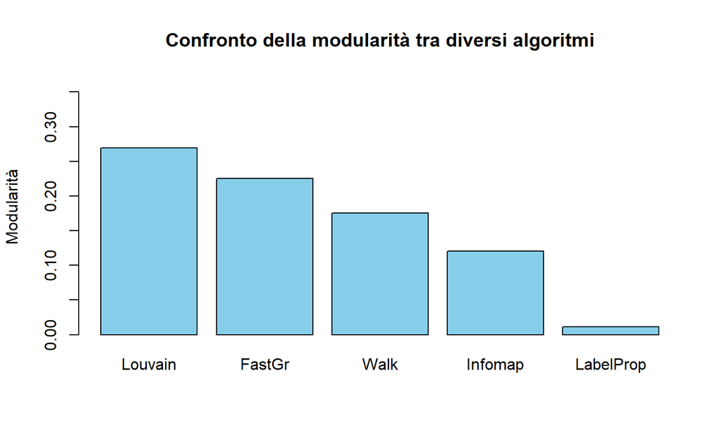

Nessun algoritmo da valori di modularità adeguati per confermare che le comunità sono ben definite.

### America

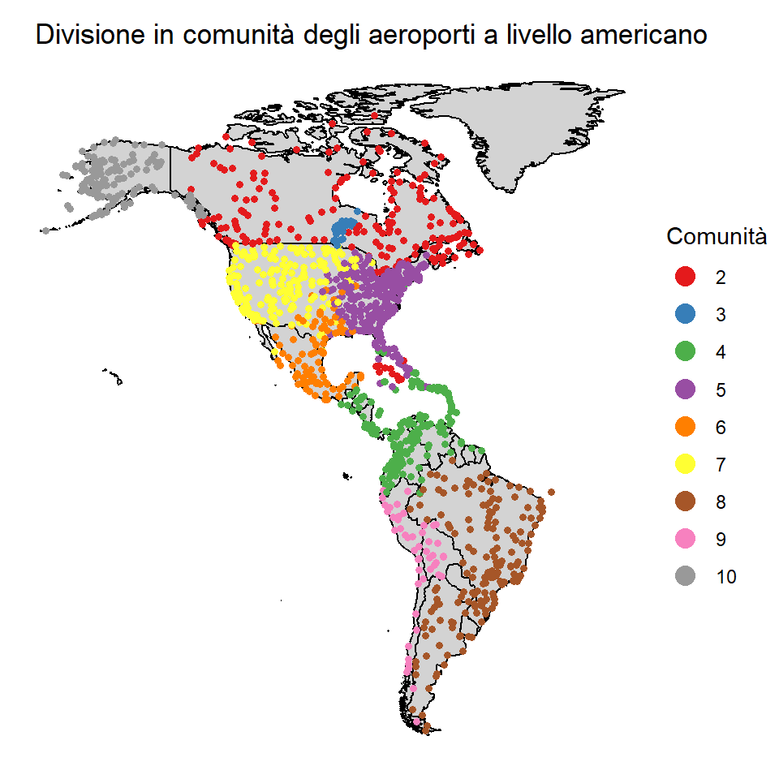

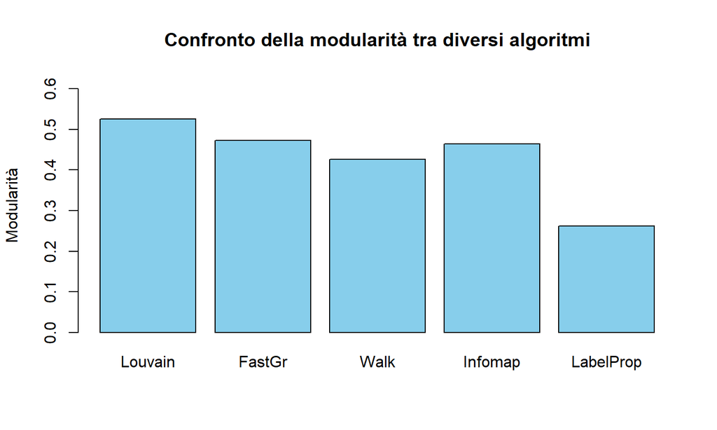

Nessun algoritmo da valori di modularità adeguati per confermare che le comunità sono ben definite. Possiamo solo dedurre che c’è una buona divisione ma non significativa.

## La quantità dei collegamenti in uscita è indicativa della qualità di un aeroporto?

I 10 aeroporti con il maggior numero di collegamenti in uscita e i 10 aeroporti con l’Hub Score più alto:

| Out Degree Centrality Nodo | Out Degree Centrality Valore |
| --- | --- |
| ATL | 915 |
| ORD | 558 |
| LHR | 527 |
| PEK | 525 |
| CDG | 524 |
| FRA | 497 |
| LAX | 489 |
| DFW | 469 |
| JFK | 456 |
| AMS | 453 |

| Hub Score Nodo | Hub Score Valore |
| --- | --- |
| ATL | 1.0000000 |
| LHR | 0.7715228 |
| ORD | 0.7465573 |
| JFK | 0.6957065 |
| LAX | 0.6792094 |
| CDG | 0.5850528 |
| FRA | 0.5281182 |
| DFW | 0.5193754 |
| SFO | 0.4701295 |
| YYZ | 0.4519899 |

Notiamo come qualche nome (ATL, ORD, LHR, CDG, FRA, LAX, DFW, JFK) si trova in entrambe le classifiche.

Vediamo se esiste una correlazione tra le seguenti misure:

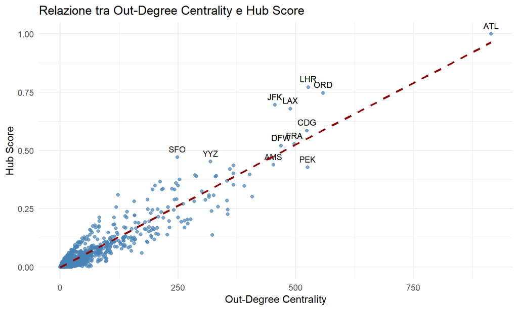

Calcoliamo il valore della correlazione usando l’indice di correlazione di Spearman.

Ne risulta che il coefficiente di correlazione è 0.79.

## La quantità di collegamenti in entrata di un aeroporto ne determina la sua importanza nella rete?

### L’importanza dei nodi da cui partono i collegamenti

I 15 aeroporti con grado d’ingresso più alto e i 15 con Pagerank più alto:

| In Degree Centrality Nodo | In Degree Centrality Valore |
| --- | --- |
| ATL | 911 |
| ORD | 550 |
| PEK | 525 |
| LHR | 524 |
| CDG | 517 |
| LAX | 497 |
| FRA | 493 |
| DFW | 467 |
| JFK | 455 |
| AMS | 450 |
| SIN | 412 |
| PVG | 405 |
| BCN | 392 |
| DEN | 373 |
| ICN | 368 |

| Pagerank Nodo | Pagerank Valore |
| --- | --- |
| ATL | 0.0096862 |
| ORD | 0.0060983 |
| LAX | 0.0058266 |
| DFW | 0.0055870 |
| CDG | 0.0051525 |
| LHR | 0.0051362 |
| SIN | 0.0049900 |
| PEK | 0.0049621 |
| DEN | 0.0048723 |
| FRA | 0.0047030 |
| JFK | 0.0046302 |
| DME | 0.0045151 |
| AMS | 0.0043248 |
| MIA | 0.0042660 |
| IST | 0.0042621 |

Possiamo pensare vedendo le prime posizioni che un aeroporto con molte connessioni in entrata riceve connessioni da nodi importanti.

Calcoliamo la correlazione per verificare questa cosa.

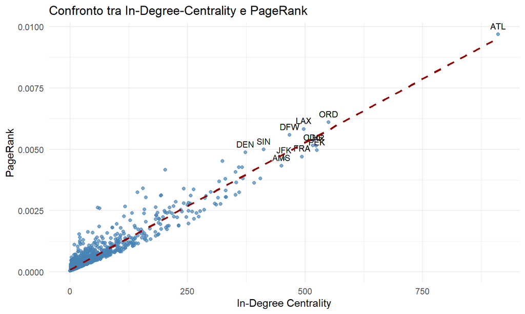

La correlazione tra In Degree Centrality e PageRank è pari a 0.84 usando Spearman.

### Il valore strategico dei collegamenti in ingresso

Il confronto con Authority Score permette di distinguere tra aeroporti che sono semplicemente popolari e quelli che hanno un ruolo strategico nel traffico globale.

| In Degree Centrality Nodo | In Degree Centrality Valore |
| --- | --- |
| ATL | 911 |
| ORD | 550 |
| PEK | 525 |
| LHR | 524 |
| CDG | 517 |
| LAX | 497 |
| FRA | 493 |
| DFW | 467 |
| JFK | 455 |
| AMS | 450 |
| SIN | 412 |
| PVG | 405 |
| BCN | 392 |
| DEN | 373 |
| ICN | 368 |

| Authority Score Nodo | Authority Score Valore |
| --- | --- |
| ATL | 1.0000000 |
| LHR | 0.7666278 |
| ORD | 0.7402591 |
| JFK | 0.7154304 |
| LAX | 0.6955180 |
| CDG | 0.5800740 |
| DFW | 0.5371428 |
| FRA | 0.5241245 |
| SFO | 0.4654227 |
| YYZ | 0.4614604 |
| AMS | 0.4428940 |
| MIA | 0.4370770 |
| DEN | 0.4337940 |
| PEK | 0.4313920 |
| ICN | 0.4070878 |

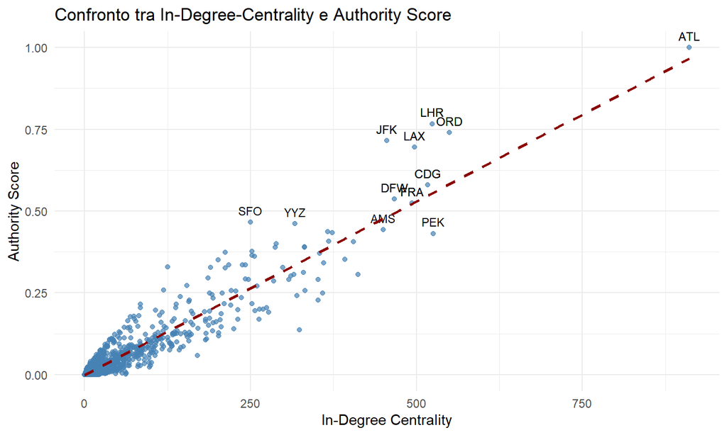

La correlazione è pari a 0.9444917.

## Qual è l’impatto della chiusura di un aeroporto o di una rotta? La resilienza della rete

Il grafo considerato è rappresentato dalla Componente Fortemente Connessa più grande che possiede 3190 nodi contro i 3257 originali e 66840 archi contro i 66933 originali. Il diametro del grafo è 13.

Usiamo il diametro come misura per determinare le variazioni nel grafo.

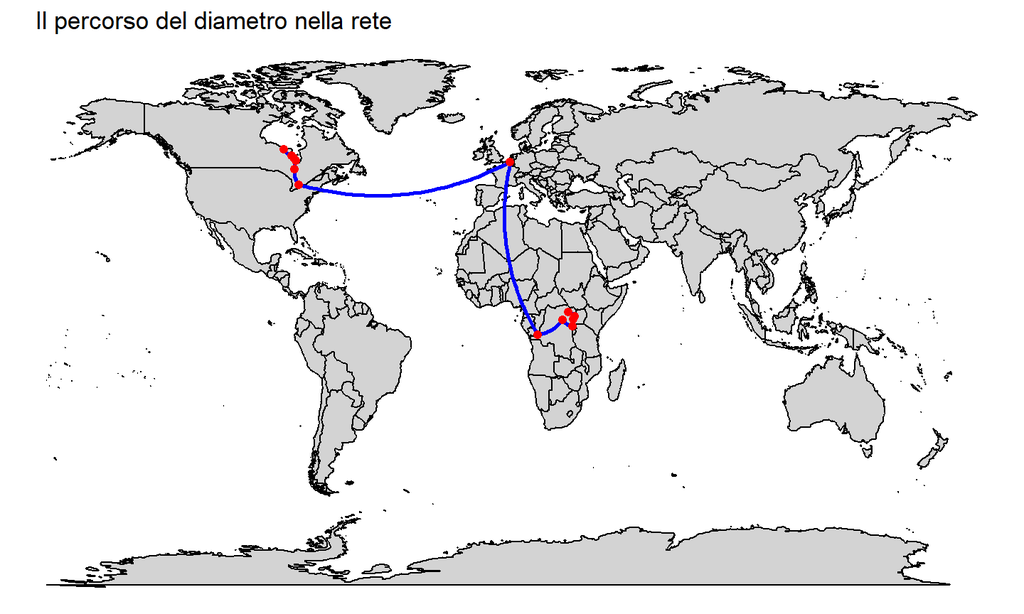

I nodi coinvolti nel diametro:

| IATA | Name | City | Country |
| --- | --- | --- | --- |
| YPO | Peawanuck Airport | Peawanuck | Canada |
| YAT | Attawapiskat Airport | Attawapiskat | Canada |
| ZKE | Kashechewan Airport | Kashechewan | Canada |
| YFA | Fort Albany Airport | Fort Albany | Canada |
| YMO | Moosonee Airport | Moosonee | Canada |
| YTS | Timmins/Victor M. Power | Timmins | Canada |
| YYZ | Lester B. Pearson International Airport | Toronto | Canada |
| BRU | Brussels Airport | Brussels | Belgium |
| FIH | Ndjili International Airport | Kinshasa | Congo (Kinshasa) |
| FKI | Bangoka International Airport | Kisangani | Congo (Kinshasa) |
| GOM | Goma International Airport | Goma | Congo (Kinshasa) |
| BNC | Beni Airport | Beni | Congo (Kinshasa) |
| BUX | Bunia Airport | Bunia | Congo (Kinshasa) |
| IRP | Matari Airport | Isiro | Congo (Kinshasa) |

Valutiamo congiuntamente le due procedure di rimozione di un nodo e la rimozione di un arco.

Gli istogrammi indicano per ogni possibile valore del diametro quanti nodi o archi, una volta tolti, rendono la rete con quel diametro.

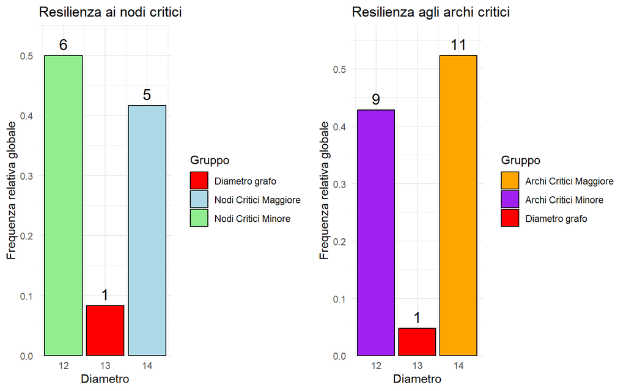

Ci sono 2859 nodi che una volta rimossi non modificano il diametro della rete, 5 che fanno aumentare questo valore e 6 che fanno diminuire questo valore.

Parlando di archi, ce ne sono 66820 che una volta rimossi non modificano il diametro della rete, 11 che fanno aumentare questo valore e 9 che fanno diminuire questo valore.

I nodi e gli archi che rendono la rete disconnessa sono identificati con il valore 0 nel calcolo del diametro e sono rispettivamente 320 e 0.

### **Quali nodi permettono di diminuire e aumentare il diametro se rimossi?**

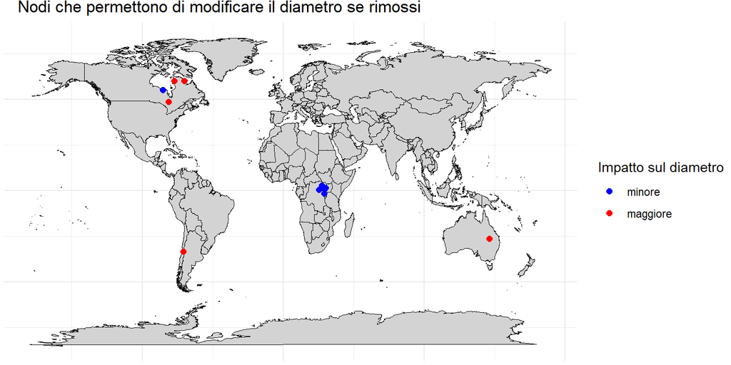

| IATA | Diametro | Name | Country | Grado |
| --- | --- | --- | --- | --- |
| FKI | 12 | Bangoka International Airport | Congo (Kinshasa) | 11 |
| IRP | 12 | Matari Airport | Congo (Kinshasa) | 5 |
| BUX | 12 | Bunia Airport | Congo (Kinshasa) | 2 |
| GOM | 12 | Goma International Airport | Congo (Kinshasa) | 4 |
| YPO | 12 | Peawanuck Airport | Canada | 6 |
| BNC | 12 | Beni Airport | Congo (Kinshasa) | 158 |
| YTS | 14 | Timmins/Victor M. Power | Canada | 8 |
| SCL | 14 | Comodoro Arturo Merino Benítez International Airport | Chile | 6 |
| CTL | 14 | Charleville Airport | Australia | 2 |
| YKG | 14 | Kangirsuk Airport | Canada | 8 |
| YPX | 14 | Puvirnituq Airport | Canada | 4 |

Molti di questi nodi appartengono al percorso del diametro: YPO, YTS, FKI, GOM, BNC, BUX, IRP.

Per esempio i nodi “FKI” e “YTS” appartengono al percorso del diametro del grafo ma se rimossi il valore del diametro cambia in modo differente.

### **In generale la rete è resiliente?**

Il numero di nodi che una volta rimossi portano la rete a diametro zero è 320. Considerando questo numero rispetto al numero totale di nodi nel grafo (3190) si può dire che la rete può essere considerata resiliente, cioè ha una buona capacità di sopportare perdite di nodi senza compromettere la sua connettività globale. Questi nodi incidono per un 10.03%.

## Quali aeroporti fungono da snodi chiave per il traffico aereo?

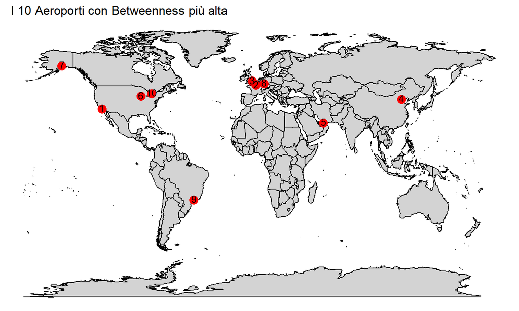

| Nodo | Betweenness | Name | City | Country |
| --- | --- | --- | --- | --- |
| LAX | 0.0824831 | Los Angeles International Airport | Los Angeles | United States |
| CDG | 0.0713237 | Charles de Gaulle International Airport | Paris | France |
| LHR | 0.0604113 | London Heathrow Airport | London | United Kingdom |
| PEK | 0.0562248 | Beijing Capital International Airport | Beijing | China |
| DXB | 0.0542967 | Dubai International Airport | Dubai | United Arab Emirates |
| ORD | 0.0541429 | Chicago O’Hare International Airport | Chicago | United States |
| ANC | 0.0537043 | Ted Stevens Anchorage International Airport | Anchorage | United States |
| FRA | 0.0512330 | Frankfurt am Main Airport | Frankfurt | Germany |
| GRU | 0.0465382 | Guarulhos - Governador André Franco Montoro International Airport | Sao Paulo | Brazil |
| YYZ | 0.0427209 | Lester B. Pearson International Airport | Toronto | Canada |

## Conclusioni

## Conclusioni

L’analisi degli aeroporti e dei loro collegamenti ha messo in luce molteplici aspetti significativi caratteristici di una rete complessa:

- una marcata eterogeneità nella distribuzione della connettività
- la formazione di comunità rispetto ai confini fisici
- come la rete supporta il fallimento dei nodi